# Analysis of MDHS Data on Contraceptive Use

Geldert Geredati Davie Chiwaya

2023-12-12

## Introduction

**Contraceptive use** plays a pivotal role in safeguarding reproductive health, and understanding its prevalence within diverse demographic groups is essential for shaping effective public health initiatives. This report delves into the present landscape of contraceptive adoption among women of reproductive age (*15-49 years*) in Malawi. Its central objective is to delineate the nuanced patterns of contraceptive usage exhibited by women actively employing such measures, considering various social and demographic characteristics.

The exploration of contraceptive use holds profound significance as it directly influences pregnancy outcomes, birth rates, and the capacity of women and their partners to plan and avert unintended pregnancies. Consequently, an in-depth analysis of the prevalent trends within different demographic cohorts allows for a more targeted approach in designing and implementing public health interventions. By shedding light on the specific characteristics that define contraceptive use, this report contributes valuable insights that can inform the development of tailored strategies aimed at promoting reproductive health and facilitating informed decision-making among women in *Malawi*.

## Data Overview

The Demographic and Health Surveys (*DHS*) are a series of standardized surveys conducted periodically in developing countries that collect data on various aspects of population, health, and nutrition.

## Comparing distributions

The *figure* below shows the disparities in contraceptive use among women, presenting a comprehensive overview of the variations observed across marital status, encompassing those using contraceptives and not using.

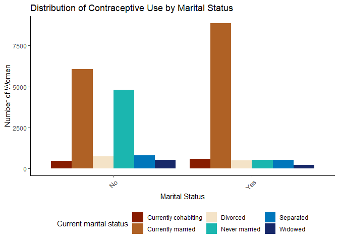

The *figure* below provides valuable insights into the distribution of age across diverse education levels, elucidating variations in age within each specific educational group. This graphical representation facilitates an understanding of the age dynamics within distinct educational strata.

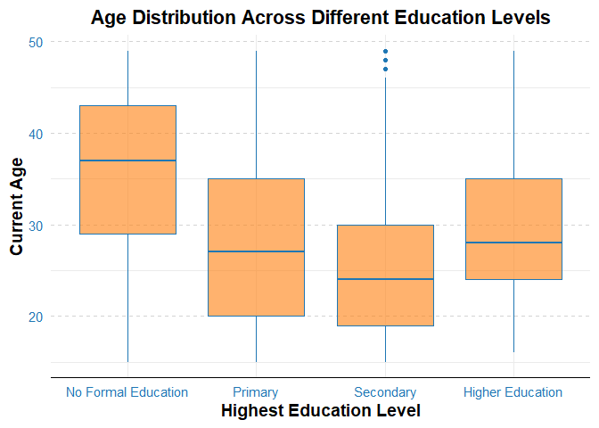

The *figure* below shows the distribution of contraceptive use within each educational level, spotlighting the diversity in contraceptive practices among women with varying educational backgrounds. This visual representation effectively underscores the variability in contraceptive choices across different education levels of among women in Malawi.

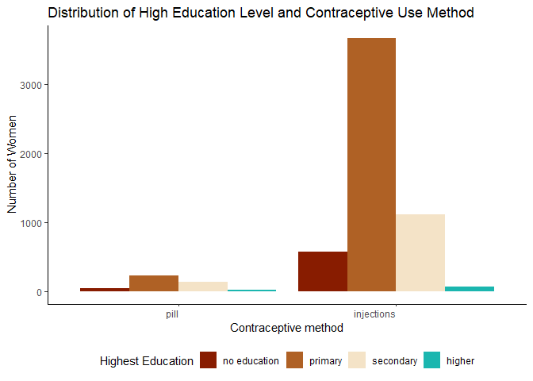

The **figure** below shows the distribution of women aged *15-49* who are currently using contraceptive pills or implants/norplant, by their current marital status. This graphical representation offers a clear overview of contraceptive methods chosen by women within specific marital categories.

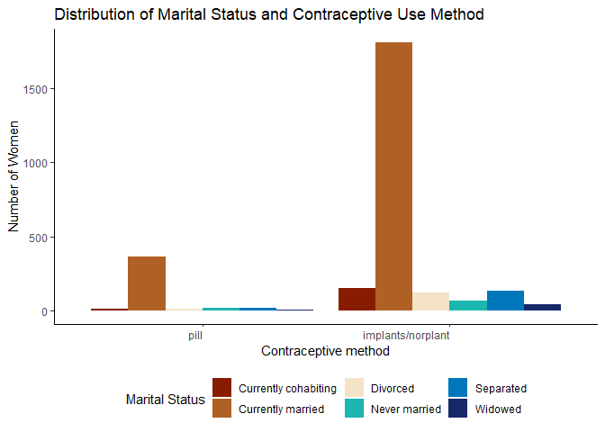

## Discussion and conclusion

This report presents a snapshot of current contraceptive use among women in the peak years of childbearing, primarily using data collected by Malawi Demographic and Health Surveys.